# R Notebook

## Introduction

Text Mining and Natural Language Processing are two of the most interesting fields right now in Data Mining. Whether you are working with tweets from some controversial political candidate or going through thousands of pages of content to discover some kind of pattern, there’s a lot you can do right now with the algorithms and packages available in R (or Python, for that matter). Livros são mídias interessantes e desafiadoras para se trabalhar, já que são textos que carregam muitas vezes significados ocultos, ironias, floreios e vocabulário mais rebuscado do que conteúdos mais imediatistas e voltados à comunicação direta, como um artigo de notícias ou um tweet. For me, as a bookworm, one of the most interesting possibilities is to take one book and dissecting it, trabalhando principalmente no sentido de produzir visualizações, verificar quais são as palavras mais frequentes num livro e realizar testes estatísticos para, por exemplo, determinar relações entre as palavras.

No entanto, este processo não é simples nem straightforward. Alguns dos desafios normalmente encontrados: * Where to obtain the book * Manual transformations and inspecting the data as you go

Fontes: http://www.sthda.com/english/wiki/text-mining-and-word-cloud-fundamentals-in-r-5-simple-steps-you-should-know https://guilhermegarcia.github.io/lusiadas.html https://rpubs.com/tsholliger/301914

## Pacotes e funções

```r
pacman::p_load(ggplot2,stopwords,janeaustenr,tokenizers,wordcloud2,tidytext,tm,readr,stringr,dplyr,wordcloud,RColorBrewer,pdftools,textdata,lexiconPT,ggrepel,igraph,ggraph)
```

## 1 Importando os arquivos

```r
?readLines
carrie <- readLines("carrie.txt",skipNul = T,encoding = "UTF-8")
comer <- readLines("comer,rezar,amar.txt",skipNul = T,encoding = "UTF-8")
cegueira <- readLines("cegueira.txt",skipNul = T,encoding = "UTF-8")
```

```r
carrie <- pdf_text('shining.pdf')
txt = txt[11:length(txt)-7]
head(txt)
```

Se for um PDF, a importação é assim e o tratamento é semelhante ao TXT

# Stopwords

```r
length(stopen)
```

```
[1] 1298
```

```r
op = oplexicon_v3.0 %>% mutate(sentiment = ifelse(polarity ==  -1, "Negative",ifelse(polarity  == 0, "Neutral","Positive"))) %>%
  rename(word = term) %>% select(word,sentiment)
op %>% count(sentiment)
```

# Quando começam os livros de verdade

```r
head(carrie,50)
```

```
 [1] "BLOOD SPORT"
 [2] ""
 [3] ""
 [4] ""
 [5] ""
 [6] ""
 [7] "News item from the Westover (Me.) weekly Enterprise, August 19, 1966:"
 [8] ""
 [9] "RAIN OF STONES REPORTED"
[10] ""
[11] "It was reliably reported by several persons that a rain of stones fell from a clear blue sky on Carlin Street in the town of Chamberlain on August 17th. The stones fell principally on the home of Mrs. Margaret White, damaging the roof extensively and ruining two gutters and a downspout valued …
[12] ""
[13] "Mrs. White could not be reached for comment."
[14] ""
[15] ""
```

[output cut: 35 more lines]

# Transformações Carrie

```r
docscarrie <- Corpus(VectorSource(carrie))
docscarrie <- docscarrie %>%
  tm_map(toSpace, "/") %>%
  tm_map(toSpace, "”") %>%
  tm_map(toSpace, "“") %>%
  tm_map(toSpace, "@") %>%
  tm_map(toSpace, "\\|") %>%
  tm_map(toSpace, "—") %>%
  tm_map(toSpace, "’") %>%
  tm_map(toSpace, "…")
inspect(docscarrie)
docscarrie <- docscarrie %>%
  tm_map(content_transformer(tolower)) %>%
  tm_map(removeNumbers) %>% # Remove numbers
  tm_map(removeWords, stopen) %>% # Remove english common stopword
  tm_map(removePunctuation) %>% # Remove punctuations
  tm_map(stripWhitespace) # Eliminate extra white spaces
  #docs <- tm_map(docs, removeWords, c("”", "“"))  # Remove your own stop word
inspect(docscarrie)
tidy_carrie <- data.frame(text = sapply(docscarrie, as.character), stringsAsFactors = FALSE) %>%
  mutate(paragraph = row_number()) %>%
  ungroup()
tidy_carrie <- tidy_carrie %>%  unnest_tokens(input = text, output = word)
head(tidy_carrie,100)
```

```r
carrie_trigrams <- tidy_carrie %>%
  unnest_tokens(trigram, text, token = "ngrams", n = 3) %>%
  tidyr::separate(trigram, c("word1", "word2", "word3"), sep = " ") %>%
  filter(!is.na(word1)) %>%
  count(word1, word2, word3, sort = TRUE)

carrie_trigrams %>%
  top_n(n = 10,wt = n) %>%
  tidyr::unite("word",word1,word2,word3,sep=" ") %>%
  mutate(word = reorder(word, n)) %>%
  ggplot(aes(n, word, fill=n)) +
  geom_col() +
  scale_fill_gradient(low="#EF3B2C",high="#CB181D")+
  labs(title = "Most frequent bigrams in 'Carrie'",y = "Bigrams",x="No. of times") +  geom_text(aes(label = n), hjust = -0.05, size = 4,
            position = position_dodge(0.5)) + theme(legend.position = "none",plot.title = element_text(hjust = 0.5))
```

[output not shown]

# Palavras mais frequentes Carrie

[output not shown]

## 3.3 palavras mais frequentes

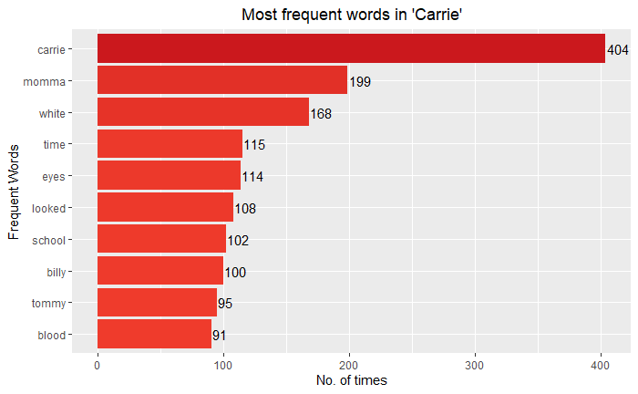

[output not shown]

[output cut: 990 more lines]

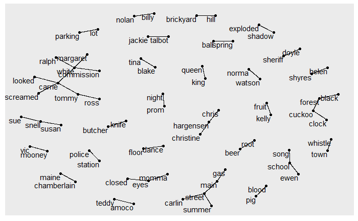

## Wordcloud Carrie

[interactive chart not shown]

## 3.4 Correlação entre termos

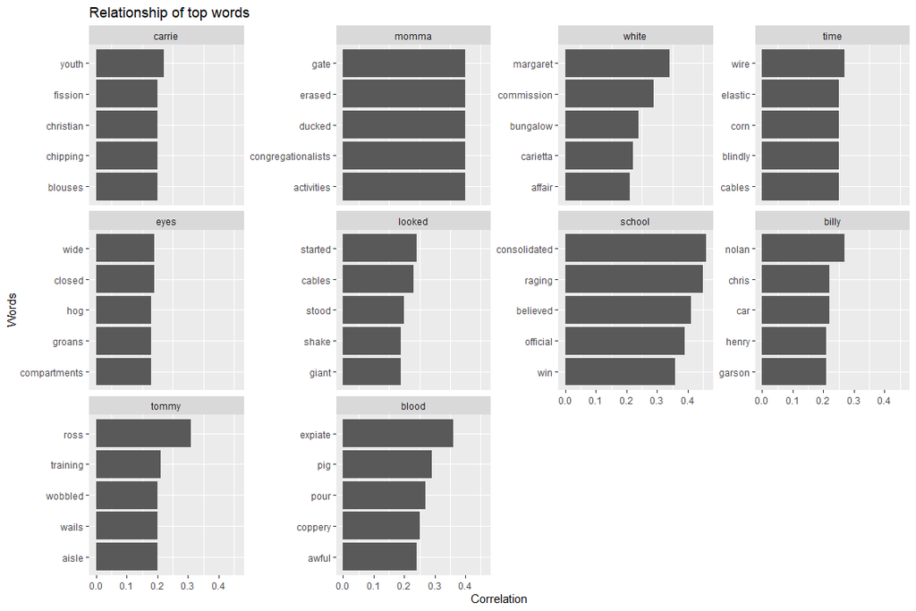

## calculando TF-IDF

| term | document | count | tf | idf | tf_idf | word |
| --- | --- | --- | --- | --- | --- | --- |
| implying | 229 | 1 | 1 | 7.561122 | 7.561122 | implying |
| advice | 322 | 1 | 1 | 7.561122 | 7.561122 | advice |
| retrospect | 352 | 1 | 1 | 7.561122 | 7.561122 | retrospect |
| essentially | 492 | 1 | 1 | 7.561122 | 7.561122 | essentially |
| loves | 520 | 1 | 1 | 7.561122 | 7.561122 | loves |
| rid | 722 | 1 | 1 | 7.561122 | 7.561122 | rid |
| cartwheels | 773 | 1 | 1 | 7.561122 | 7.561122 | cartwheels |
| hmmmm | 826 | 1 | 1 | 7.561122 | 7.561122 | hmmmm |
| vanity | 960 | 3 | 1 | 7.561122 | 7.561122 | vanity |
| gratefully | 1130 | 1 | 1 | 7.561122 | 7.561122 | gratefully |

[output cut: 10 more lines]

#### Sentiment Analysis - comparação de 3 lexicons

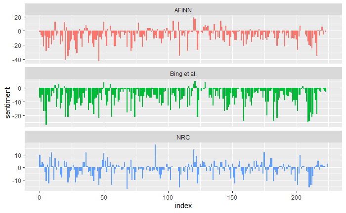

```r
afinn = tidy_carrie %>%
  inner_join(get_sentiments("afinn")) %>%
  group_by(index = paragraph %/% 20) %>%
  summarise(sentiment = sum(value)) %>%
  mutate(method = "AFINN")
bing_and_nrc <- bind_rows(
  tidy_carrie %>%
    inner_join(get_sentiments("bing")) %>%
    mutate(method = "Bing et al."),
  tidy_carrie %>%
    inner_join(get_sentiments("nrc") %>%  filter(sentiment %in% c("positive","negative"))
    ) %>%
    mutate(method = "NRC")) %>%
  count(method, index = paragraph %/% 20, sentiment) %>%
  tidyr::spread(sentiment, n, fill = 0) %>%
  mutate(sentiment = positive - negative)
bind_rows(afinn,
          bing_and_nrc) %>%
  ggplot(aes(index, sentiment, fill = method)) +
  geom_col(show.legend = FALSE) +
  facet_wrap(~method, ncol = 1, scales = "free_y")
```

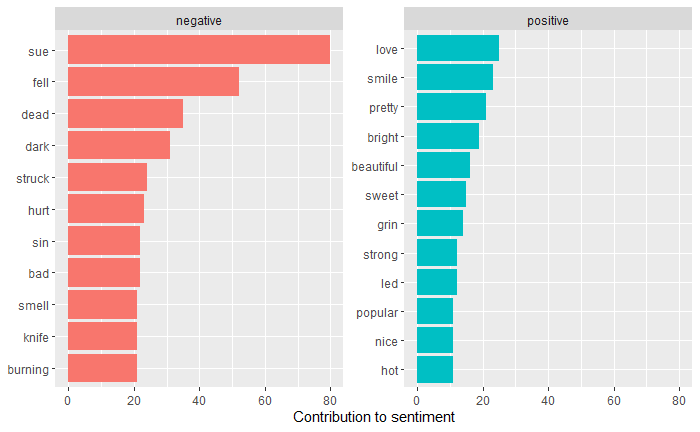

```r
bing_word_counts %>%
  group_by(sentiment) %>%
  top_n(10) %>%
  ungroup() %>%
  mutate(word = reorder(word, n)) %>%
  ggplot(aes(n, word, fill = sentiment)) +
  geom_col(show.legend = FALSE) +
  facet_wrap(~sentiment, scales = "free_y") +
  labs(x = "Contribution to sentiment",
       y = NULL)
```

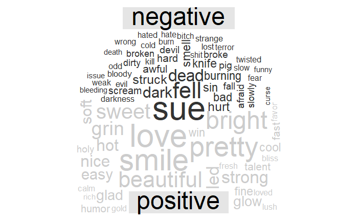

```r
tidy_carrie %>%
  inner_join(get_sentiments("bing")) %>%
  count(word, sentiment, sort = TRUE) %>%
  acast(word ~ sentiment, value.var = "n", fill = 0) %>%
  comparison.cloud(colors = c("gray20", "gray80"),
                   max.words = 100)
```

# A fazer:

Ângulos a explorar: * Porque escolhi esse livro * pacote tm para criação e gestão do corpus * transformações dos dados * stopwords * palavras mais frequentes * wordcloud * associação entre palavras: - momma - white - blood * por que criar uma document matrix * sentiment analysis com 3 lexicons diferentes

- explicar o que é sparsity
- tf-idf: o que é e para quê usar https://hub.packtpub.com/9-useful-r-packages-for-nlp-text-mining/#:~:text=OpenNLP%20is%20an%20R%20package,for%20natural%20language%20processing%20activities.&text=It%20provides%20functions%20for%20sentence,the%20Apache%20OpenNLP%20chunking%20parser. http://uc-r.github.io/sentiment_analysis http://uc-r.github.io/tidy_text

dividir o artigo em 2 partes parte 1: wordcloud, correlation e chatterplot bar plots(invertidos) de palavras mais relacionadas com cada uma das top10 - OK chatterplot - NÃO (explicar) - https://towardsdatascience.com/rip-wordclouds-long-live-chatterplots-e76a76896098 bigrams tf-idf

parte 2: sentiment analysis construir dataframe de sentimentos grid de palavras x sentimento bar plot de nº de palavras x sentimento radar chart de palavras x sentimento bar plots(invertidos) de palavras mais relacionadas com cada sentimento